# Shiny 기반 방역관리 위험도 평가 대시보드

RSQLite, shinyauthr 등 여러 R package를 이용한 웹 기반 방역관리 위험도 평가 대시보드 제작 과정

Author

Yeongho Kim

Published

June 5, 2023

`R Shiny`의 활용성은 무궁무진합니다. 다양한 Shiny 전용 패키지와 함수, Javascript, CSS와의 연계성 등 다양한 기능을 활용해 반응형 웹페이지 제작이 가능합니다.

본 글에서는 이렇게 무궁무진한 `R Shiny`로 *웹 기반 방역관리 위험도 평가 대시보드*을 제작한 경험을 공유하며 사용한 여러 기능을 소개하려고 합니다.

UI의 전반적인 레이아웃은 `Shinydashboard`를 사용했으며 본문에선 `Shinydashboard`와 `Shiny`의 기본 함수에 대한 설명은 생략합니다. 두 패키지에 대한 기본적인 함수 및 구조 설명은 아래 링크를 참조하세요.

`Shinydashboard` package : [Shiny Dashboard](https://rstudio.github.io/shinydashboard/)

`Shiny` package : [Mastering Shiny](https://mastering-shiny.org/)

## 1. DB : `DBI` & `RSQLite`

본 대시보드는 사용자별로 데이터 무결성이 유지되어야 했고 지속적인 데이터 수집이 필요했기에 DB를 따로 운용하기로 했습니다.

DB를 다룰 수 있는 `DBI` 패키지와 간단한 DBMS인 SQLite를 사용할 수 있는 `RSQLite`를 사용하여 DB 설계 및 유지 보수를 진행했습니다.

다음과 같이 DB connect / disconnect 함수를 따로 지정하여 초기 설정을 해줍니다.

```r
library(DBI);library(RSQLite)

# connection
con <- function() {
  DBI::dbConnect(SQLite(),
            dbname = "[path]/[DBname].sqlite")

  #기존에 SQLite DB가 존재한다면 Connected, 아니면 create DB
}

# disconnection
discon <- function(){
  dbDisconnect(con())
}
```

`DBI` 패키지의 대부분의 함수는 parameter로 DBIconnection object를 요구합니다. 따라서 다음과 같이 `con()` 이라는 함수를 parameter로 호출하여 DBI의 함수를 사용할 수 있습니다.

```r
# Example :  DBname : database.sqlite

DBI::dbExecute(con(), "CREATE TABLE table1 (
                                 keyvalue INTEGER(10) PRIMARY KEY,
                                 value1 DATE,
                                 value2 VARCHAR(20) CHECK(value2 IN ('a', 'b', 'c'))
                                 )")
discon()

DBI::dbExecute(con(), "INSERT INTO table1 VALUES (?, ?, ?)", c(1, "2023-05-24", "a"))
DBI::dbGetQuery(con(), "SELECT * FROM table1")
```

`dbExecute` 함수를 통해 실행하고자 하는 SQL문을 실행시킵니다. 이전에 생성한 `con()` 함수를 통해 DB에 연결한 뒤 SQL문을 문자열 형태로 입력하여 실행합니다. 또한 SQL문에 동적으로 R의 변수를 넣어야하는 경우, `?`를 통해 SQL문을 입력한 뒤에 `?`에 넣고자 하는 순서에 맞게 뒤에 vector 형태로 입력하면 됩니다.

`dbGetQuery`의 경우`SELECT문`같이 SQL Query의 결과를 갖고 오고 싶은 경우 사용합니다. 추출 결과를 dataframe 형태로 가져옵니다.

본 대시보드 제작 과정에선 `RSQLite`를 이용하여 Table 4개를 운용하였고, `SQLite`에서도 당연히 참조 무결성 제약조건(PK-FK)을 생성할 수 있기때문에 직접 R에서 코드를 작성하지 않고 SQL문을 통해 미리 제약조건을 생성할 수 있습니다.

## 2. Log in / Register : `shinyauthr` Customizing

`Shiny` 패키지 중 Log in/Log out UI를 제공하는 패키지는 대표적으로 `shinymanager`와 `shinyauthr`가 있습니다. 그러나 `Shinymanager`에는 회원가입 기능을 추가하기가 어려운 부분이 있어 `shinyauthr`를 사용하되, 살짝 코드를 수정하여 Log in/Log out/Register option을 Web에 추가하였습니다.

`shinyauthr` package의 주요 함수는 다음과 같습니다.

- `loginUI` : log in UI를 보여주는 함수로 화면에 나타나는 메시지를 수정가능합니다.
- `loginServer` : log in의 base가 되는 database를 설정하고 id, password 설정, 쿠키 로그인 설정이 가능합니다.
- `logoutUI` : log out UI를 보여주는 함수로, 화면에 나타나는 메시지 및 css style을 수정할 수 있습니다.
- `logoutServer` : log out시 실행되는 함수로, 사용자의 권한(`user_auth`)를 boolean reactive 형태로 관리합니다.

login logic : `loginUI`에 ID/PW 입력 -> `loginServer`에서 확인 후 권한 부여

logout logic : `logoutUI`의 logout button 클릭 -> `logoutServer`에서 reactive하게 user_auth 상태 변경

(자세한 내용은 [shinyauthr package](https://github.com/PaulC91/shinyauthr) 참조)

UI의 일반적인 구성은 다음과 같습니다.

```r
ui <- dashboardPage(

  skin = "black",
  header = dashboardHeader(
    title = ("방역관리 위험도 평가"),
    tags$li(class = "dropdown", style = "padding: 8px;", shinyauthr::logoutUI("logout"))
  ),

  sidebar = dashboardSidebar(
    # menu
  ),

  body = dashboardBody(
    shinyauthr::loginUI("login",
                        title = h4(HTML("<center> 이름과 전화번호를 입력해주세요 </center>")),
                        user_title = "이름",
                        pass_title = "전화번호",
                        login_title = "로그인",
                        error_message = h6("유효하지 않은 정보입니다. 처음이시라면 회원가입을 눌러주세요.", style = "color : red"),
                        additional_ui = tags$a(
                          actionBttn(
                            inputId = "register",
                            label = "회원가입",
                            style = "fill",
                            color = "danger",
                            size = "xs"
                          )
                        )
    ),
    # menu 별 UI
  )
)
```

본 UI는 `shinydashboard`를 기반으로 구성되어있습니다. 따라서 header에 logout 버튼을 생성하려 했고, dashboradBody에 login UI를 배치해 메인 화면에 바로 로그인 화면이 나오도록 하였습니다. 또한 loginUI의 parameter를 원하는 텍스트로 설정하였고, 회원가입은 `additional_ui` parameter를 이용하여 추가적으로 `actionBttn`에 따른 UI가 생성되도록 설계하였습니다. 아래는 로그인 화면과 회원가입 버튼 클릭 시의 화면입니다.

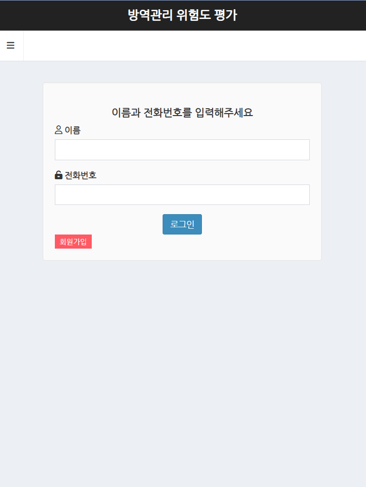

로그인 화면

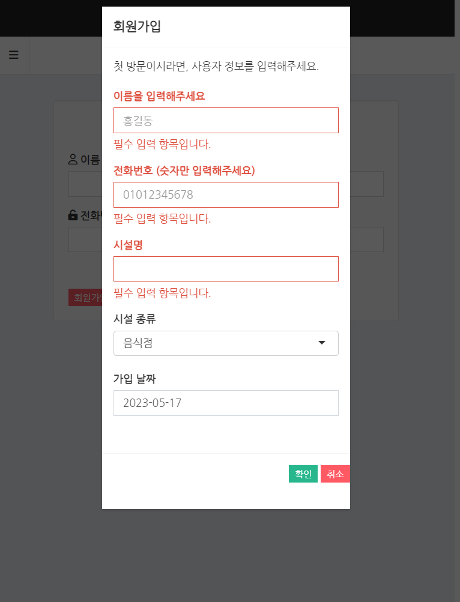

회원가입 화면

그러나 `loginServer` 함수의 경우, 기본 ID/PW 저장 DB 세팅이 `tidyverse` 패키지의 `tibble`형태로 작성되어 있기 때문에 동적 형태의 DB를 지원하고 있지 않습니다.

예를 들어 회원 가입 후 즉시 로그인하기 위해선 새로운 사용자의 정보가 반영된 DB를 reactive하게 Call 해야하는데 이 부분에 제약사항이 있었습니다.

따라서 reactive하게 DB 정보를 받아올 수 있도록 함수를 수정해야 했습니다. (다음 링크 참조 : [Shinyauthr loginServer Customizing](https://github.com/thisis05/shinyauthr_with_reactive_DB))

```r
server <- function(input, output, session) {

#login/logout function--------------------------------------

  credentials <- Myloginserver(
      id = "login",
      log_out = reactive(logout_init()),
      reload_on_logout = TRUE
  )

  logout_init <- shinyauthr::logoutServer(
    "logout",
    reactive(credentials()$user_auth)
  )

  userdata <- reactive({
    credentials()$info
  })

}
```

`Myloginserver`는 customizing 된 `shinyauthr::loginServer` 함수이며 미리 생성된 사용자 정보 DB table을 바탕으로 로그인이 되도록 설정되어 있습니다. 기본적으로 `shinyauthr::loginServer` 함수는 `info`와 `user_auth`라는 변수를 담고 있습니다.

- `info`의 경우, 로그인의 기반이 되는 DB 내에서 사용자의 ID/PW에 해당하는 row의 컬럼 값들을 table 형태로 저장하고 있습니다.
- `user_auth`의 경우, 권한이 있느냐 없느냐를 나타내며 로그인이 완료될 시 TRUE, 아닐 시 FALSE 값을 가지게 됩니다.

따라서 `credentials`이라는 변수에 `loginServer` 함수를 저장하면 reactive한 `user_auth`값과 `info`값을 지니게 됩니다.

`reload_on_logout = TRUE`로 설정하면 로그 아웃 시 세션이 초기화되어 자동으로 로그인 화면으로 돌아갑니다. 기본적으로 세션이 초기화되면 `credentials()$user_auth == FALSE`가 되어 로그인이 취소되고 권한이 사라지므로, 좀 더 확실한 로그아웃을 위해 다음과 같은 옵션을 설정하였습니다.

`logout_init`은 `logoutServer` 함수로 `logoutUI`의 ID를 받아온 뒤, reactive 함수에 따라 logout 버튼을 보여줄 지 숨길 지 반응형으로 설정할 수 있습니다. 기본적으로 권한이 있느냐 없느냐에 따라 logout 버튼을 보여주거나 숨겨야하기때문에 위와 같이 설정해줍니다.

또한 `shinyauthr` 패키지는 로그인 / 로그아웃 UI만 보여주고 로그인 상태에 따른 UI 변환 기능은 없기 때문에, 수동으로 로그인 완료시에만 보여주고 싶은 UI에는 옵션을 추가해야 합니다.

```
req(credential()$user_auth)
```

다음과 같은 옵션을 `uiOutput`을 이용하여 `renderUI`에 추가하거나, 아래와 같이 `MenuOutput` 과 `renderMenu`를 이용하여 `shinydashboard`의 Menu 자체를 숨길 수 있습니다.

```r
#UI

ui <- dashboardPage(

  # others

  sidebar = dashboardSidebar(
    sidebarMenu(
      id = "tabs",
      menuItemOutput("check")
    )
  ),

  body = dashboardBody(
    tabItems(
      tabItem(tabName = "check",
              # UI contents
      )
    )
  )
)
```

```r
#Server
server <- function(input, output, session) {

  output$check <- renderMenu({
    req(credentials()$user_auth)
    menuItem("방역관리자 업무 점검", icon = icon("check", lib ="glyphicon"), tabName = "check")
  })
}
```

## 3. 필수 응답 설문 설정 : `shinyvalidate`

`shinyvalidate` package는 `selectInput`, `numericInput` 등 `Input` function에 대해 사용자의 입력값에 대한 제약조건을 걸 수 있는 package입니다.

기본적으로 필수적으로 응답해야는 부분에 대해 설정할 수 있으며, ‘<’ 등의 연산자를 사용한 제약조건, ‘email’ 형식 제약조건 등 여러가지 option이 있습니다.

본 개발에선 필수 응답 설문 항목에 대한 설정을 위해 다음과 같이 `shinyvalidate` package를 사용하였습니다.

```
[validation name] <- shinyvalidate::InputValidator$new()
[validation name]$add_rule("input$[input variable]", sv_required("[Warning message]"))
```

기본적인 Logic은 다음과 같습니다.

1. `InputValidator$new()`를 통한 validation 변수 선언
2. `add_rule`을 통한 `input variable`별 Warning Message 작성

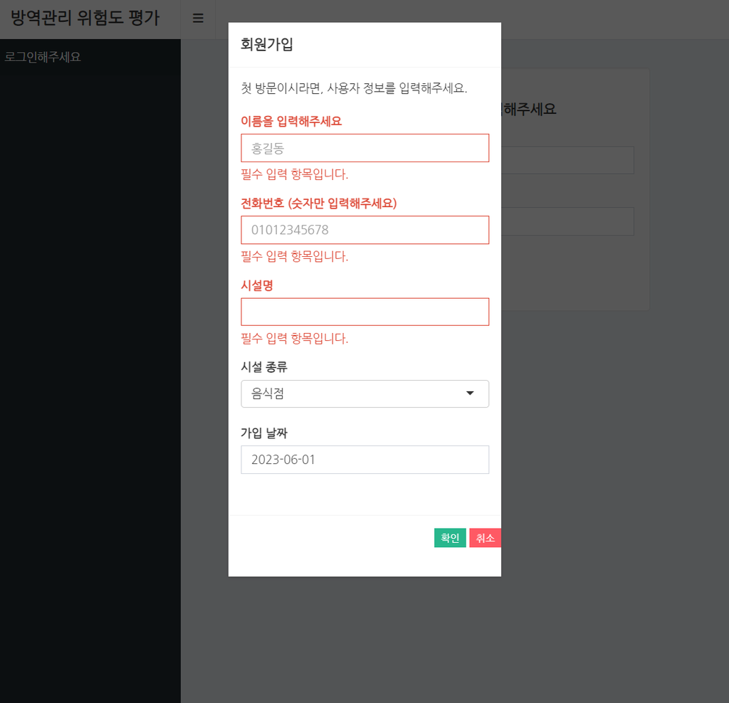

회원가입 시 shinyvalidate 사용 예시

다음과 같이 필수 입력 항목의 경우, 응답하지 않을 시 기본적으로 빨간색 테두리와 작성한 경고 메시지가 뜨게 됩니다.

추가적으로 이러한 필수 응답 항목에 답하지 않을 시 다음단계로 지나가지 못하게 제약조건을 추가할 수 있습니다.

```
    1. req([validation name]$is_valid())

    2. if([validation name]$is_valid())
```

다음과 같은 옵션을 추가하여 `renderUI` 혹은 `actionButton` click시의 전제 조건으로 추가하여 Web 설계가 가능합니다.

## 4. 이 외

### (1) `reactable` : reactive download to csv

admin을 위한 web page 제작 과정에서, DB table 들로부터 받아온 사용자 정보를 `reactable`을 이용하여 다음과 같이 제작하였습니다.

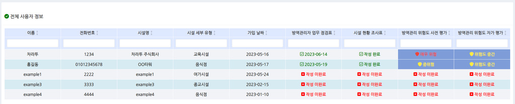

사용자 정보

이러한 table을 csv로 다운로드 받을 수 있게 하면서도, 만약 사용자가 일부 사용자의 정보를 확인하고 싶어 검색 기능을 사용했을 때 보여지는 subset table을 reactive하게 csv로 다운로드 받을 수 있게 하려했습니다.

이 부분은 [Reactable 공식 문서](https://glin.github.io/reactable/articles/javascript-api.html)의 JavaScript API 이용 부분을 차용하여 작성하였습니다.

```r
box(width = 12, title = "전체 사용자 정보" %>% h5c,
                    reactableOutput("infotable"),
                    br(),
                    htmltools::browsable(
                      tagList(
                        tags$button(
                          tagList(fontawesome::fa("download"), "Download CSV"),
                          onclick = "Reactable.downloadDataCSV('user_info', '[filename].csv')"
                        )
                      )
                    )
    )
```

### (2) `lapply`를 이용한 설문 UI 간단하게 만들기

만약 설문의 스타일이 간단하거나 (Ex: 예/아니오 유형, 체크 유형, 점수 유형) 반복되는 경우 `lapply`함수를 통해 좀 더 간단하고 정갈하게 UI 및 Server 코드를 작성할 수 있습니다.

예를 들어, 해당하는 항목에 체크하는 형식의 설문이라면, 아래와 같이 미리 설문내용만 list 형태로 만들어 놓을 수 있습니다.

```r
# example 5개 Question

Q_list <- c(
    " 시설 위험도 평가 후 시설 별 맞춤형 방역관리 지침을 마련하였는가?",
    " 정기적으로 종사자들에게 방역 수칙 교육·안내 하였는가?",
    " 발열 및 호흡기 증상 유무를 확인하고 증상이 있는 경우 즉시 검사받도록 안내하였는가?",
    " 감염병 예방수칙 홍보 안내문을 잘 보이는 곳에 배치 하였는가?",
    " 환기 대장 및 소독 대장을 배치 하였는가?"
)

# Shiny Input 함수의 ID를 각 설문 항목별 name으로 지정 (이 때 DB를 사용하실 거라면 DB의 컬럼명으로 ID를 지정하면 간편합니다)
names(Q_list) <- paste0("q", 1:5)
```

다음과 같이 설문 내용을 정리한 변수를 기반으로 `Shiny` 코드를 작성할 수 있습니다.

```r
# UI code
  lapply(names(Q_list)[1:5], function(x){
                              shiny::checkboxInput(x, Q_list[[x]], value = F)
                             })

# Server code

server <- function(input, output, session){

  ## 답변 여부에 따라 Yes or No 형식으로 저장
  inputlist <- lapply(names(Q_list), function(x){
      if(input[[x]]){
        "Yes"
      }else{
        "No"
      }
  })

  ## DB에Insert (DB 컬럼 순서에 맞게)
  DBI::dbExecute(con(), paste0("INSERT INTO [table name] values ('", paste(unlist(inputlist), collapse = "', '"), "')") )
  discon()
}
```

`Shiny`의 UI 내에서도 간편하게 위와 같이 `lapply` 함수를 사용하여 Input 함수를 나타내는 것이 가능합니다.

`Input[[x]]`로 사용자의 입력 내용에 접근 가능하므로 다음과 같이 `inputlist`로 Input 값에 접근에 DB에 저장할 수 있습니다.

설문 내용을 value로, Input ID 및 DB columnname을 name으로 할 시 좀더 간편하게 코드 작성이 가능합니다.

답변 유형(Yes or No, 점수 등등)에 따라 설문 datatable을 만들어 놓은 뒤 이에 맞게 datatable 컬럼 별로 `lapply` 함수를 잘 사용하여 UI 코드를 작성하면 보다 간편하게 `Shiny`를 이용하실 수 있습니다.

## 이슈들

1. shiny for mobile (IOS 문제)
2. Reactable cell에서 JS를 이용한 button에 columname 값 전달 : [reactable issue](https://github.com/glin/reactable/issues/89)
3. UI design

## 마치며

R만을 이용하여 Server와 UI를 동시에 제작하고 배포할 수 있다는 것이 **R Shiny** 의 가장 큰 장점입니다. 또한 오픈 소스가 활성화되어 있어 다양한 사용자 개발 library를 이용할 수 있으므로 사용하고 싶은 기능은 웬만하면 사용이 가능하며, 기존 library의 함수를 원하는 방식으로 변형하여 사용할 수도 있습니다. JavaScript나 CSS와도 호환이 잘 되기 때문에 UI 디자인까지 R이라는 한 Tool로 작업이 가능하기 때문에 상당히 편리합니다.

본 글에선 이러한 **R Shiny** 웹 App의 기반이 되는 로그인 시스템, DB 운용 등 잘 알려지지 않은(?) 여러가지 세세한 기능과 가능성에 대해 소개해보았습니다.

이외에 여러 package를 공부해가며 나만의 Shiny Web App을 제작해보는 과정 역시 재미있으니, 많은 분들께서 **R Shiny**를 이용하여 멋진 웹 페이지 제작에 참여해보시길 바라겠습니다.